# Summarize GBLUP and MultiBLUP

11 September, 2020

This script reads in results from the LDAK software to summarize predictive ability for the GBLUP and MultiBLUP models. The output is an RData file (reports/model_summary.RData) containing a data frame summary for each model and a data frame comparing the two.

# Setup

Load required packages and set root directory

```r
knitr::opts_knit$set(root.dir = "~/Documents/AA-GenomicPrediction",
                     warning = FALSE)

knitr::opts_chunk$set(fig.width = 6)

library(tidyverse)
library(broom)
```

## Load data

#### Read in results from `src/03_summarize_gblup.R` and `src/06_summarize_multiblup.R`

- **gblup_h2** - heritability from GBLUP model
- **gblup_llik** - log likelihood for GBLUP model
- **gblup_pa** - cross-validation for GBLUP model
- **multiblup_h2** - heritability from MultiBLUP model
- **multiblup_llik** - log likelihood for MultiBLUP model
- **multiblup_pa** - cross-validation for MultiBLUP model

```r
load("reports/gblup.RData")
load("reports/multiblup.RData")
```

#### Define grouping categories by trait

- **aa_fam** - amino acid family (based on precursor)
- **aa_cat** - type of measurement (absolute, relative to total, or family ratio)

```r
# read in amino acid trait ids
aa_fam <- unique((gblup_pa$trait)) %>%
  tibble::enframe() %>%
  mutate(
         # add amino acid biochemical family ids (based on precursor)
         family = ifelse(grepl("asp|thr|met|asp|AspFam", value) & !grepl("ile", value),
                         "aspartate",
                         ifelse(grepl("arg|glu|gln|pro|his|GluFam", value),
                                "glutamate",
                                ifelse(grepl("gly|ser|SerFam", value),
                                       "serine",
                                       ifelse(grepl("phe|tyr|trp|ShikFam", value),
                                              "aromatic",
                                              ifelse(grepl("total", value),
                                                     "total", "BCAA_pyruvate"))))),
         # add type of measurement (absolute, relative, ratio
         aa_cat = ifelse(!grepl("_", value), "absolute",
                         ifelse(grepl("_t", value), "relative",
                                "family"))) %>%
  rename(trait = "value")

head(aa_fam)
```

| name | trait | family | aa_cat |
| --- | --- | --- | --- |
| 1 | ala | BCAA_pyruvate | absolute |
| 2 | arg | glutamate | absolute |
| 3 | asp | aspartate | absolute |
| 4 | gln | glutamate | absolute |
| 5 | glu | glutamate | absolute |
| 6 | gly | serine | absolute |

```r
write.csv(aa_fam,
          "data/processed/aa_family_ids.csv",
          row.names = FALSE)
```

# GBLUP

Based on five ten-fold cross validations with a one-fold hold out (50 total observations)

**Variables in gblup_pa:**

- ID2 = Arabidopsis ecotype
- Phenotype = observed phenotype
- Profile1 = predicted phenotype (mean centered)
- Effect = intercept (mean) for training set

See LDAK documentation on profile scores - http://dougspeed.com/profile-scores/

### Visual check of cross-validations

Quality check to make sure cross-validation is working as expected (e.g. each training/test set is different)

There should be a total of 50 cross-validations per trait (ten-fold cross-validation with a one-fold hold out)

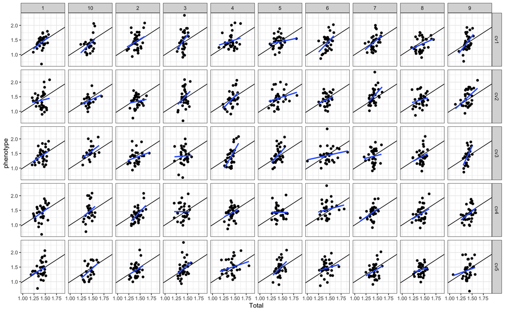

```r
gblup_pa %>%
  filter(trait %in% "ala") %>%
  # mutate(predicted = Profile1 + Effect) %>%
  ggplot(aes(x = Total, y = phenotype)) +
  geom_abline(intercept = 0, slope = 1) +
  geom_point() +
  geom_smooth(method = "lm", se = FALSE) +
  facet_grid(cvnum ~ fold) +
  theme_bw()
```

**Metrics:**

- prediction accuracy = $r_{\widehat{g},g}$
- reliability = $r^2_{\widehat{g},g}/h^2$
- bias = $b(\widehat{g},g)$
- MSE = $\frac{1}{n}\sum{(g - \widehat{g})^2}$

```r
gblup_summary <- gblup_pa %>%
  left_join(., gblup_h2) %>%
  filter(!is.na(phenotype)) %>%
  # group by trait, cross-validation, and fold
  group_by(trait, cvnum, fold) %>%
  # add mean value for training set to predicted values
  # mutate(predicted = Profile1 + Effect) %>%
  # estimate predictive accuracy, reliability, and MSE
  summarize(gblup_h2 = mean(Heritability),
            gblup_pa = cor(Total, phenotype, use = "complete.obs"),
            gblup_reliability = gblup_pa^2/gblup_h2,
            gblup_bias_slope = coef(lm(phenotype ~ Total))["Total"],
            gblup_mse = mean((phenotype - Total)^2)) %>%
  ungroup()
head(gblup_summary)
```

| trait | cvnum | fold | gblup_h2 | gblup_pa | gblup_reliability | gblup_bias_slope | gblup_mse |
| --- | --- | --- | --- | --- | --- | --- | --- |
| ala | cv1 | 1 | 0.696264 | 0.4247019 | 0.25905649 | 1.2359297 | 0.04034458 |
| ala | cv1 | 10 | 0.696264 | 0.4652194 | 0.31084343 | 1.5051579 | 0.06104671 |
| ala | cv1 | 2 | 0.696264 | 0.2869210 | 0.11823627 | 0.9118381 | 0.07052305 |
| ala | cv1 | 3 | 0.696264 | 0.3814362 | 0.20896327 | 2.1757786 | 0.09679392 |
| ala | cv1 | 4 | 0.696264 | 0.1987367 | 0.05672599 | 0.5015869 | 0.06697986 |
| ala | cv1 | 5 | 0.696264 | 0.1801819 | 0.04662818 | 0.3273082 | 0.04464005 |

### Summary of GBLUP results

Export a summary table of results for GBLUP model (Table 1)

Note: RMSE determined as $\sqrt\frac{RMSE^2_1+...+RMSE^2_k}{k}$ where $k$ is the number of cross-validations. See discussion at https://stats.stackexchange.com/questions/85507/what-is-the-rmse-of-k-fold-cross-validation

```r
table1 <- gblup_summary %>%
  # calculate statistics for each trait
  group_by(trait) %>%
  summarize_at(vars(gblup_pa,
                    gblup_reliability,
                    gblup_bias_slope,
                    gblup_mse),
               list(mean = ~mean(., na.rm = TRUE),
                    se = ~sd(., na.rm = TRUE)/sqrt(length(.)))) %>%
  mutate(gblup_rmse = sqrt(gblup_mse_mean)) %>%
  # took this out because it doesn't work as well for MSE
  # mutate_if(is.numeric, round, 3) %>%
  ungroup() %>%
  # add amino acid family ids
  left_join(aa_fam, ., by = "trait") %>%
  # reorder family names
  mutate(family = fct_relevel(family, "aromatic", after = 4)) %>%
  # sort by type of trait (abs, rel, fam) and family id
  arrange(aa_cat, family) %>%
  select(aa_cat,
         family,
         trait,
         gblup_pa_mean,
         gblup_pa_se,
         gblup_reliability_mean,
         gblup_reliability_se,
         gblup_bias_slope_mean,
         gblup_mse_mean,
         gblup_rmse) %>%
  mutate_if(is.numeric,
            round,
            digits = 4)

# export table
table1 %>%
  write_csv(., "reports/table1_gblup_summary.csv")

head(table1)
```

| aa_cat | family | trait | gblup_pa_mean | gblup_pa_se | gblup_reliability_mean | gblup_reliability_se | gblup_bias_slope_mean | gblup_mse_mean | gblup_rmse |
| --- | --- | --- | --- | --- | --- | --- | --- | --- | --- |
| absolute | aspartate | asp | 0.3414 | 0.0279 | 0.1573 | 0.0202 | 0.9602 | 0.0030 | 0.0550 |
| absolute | aspartate | met | 0.3841 | 0.0266 | 0.2244 | 0.0237 | 0.9693 | 0.0006 | 0.0243 |
| absolute | aspartate | thr | 0.0985 | 0.0216 | 0.0753 | 0.0133 | 0.5717 | 0.0182 | 0.1348 |
| absolute | aspartate | AspFam | 0.3269 | 0.0306 | 0.1587 | 0.0218 | 0.9703 | 0.0007 | 0.0266 |
| absolute | BCAA_pyruvate | ala | 0.3173 | 0.0219 | 0.1784 | 0.0209 | 1.0292 | 0.0620 | 0.2490 |
| absolute | BCAA_pyruvate | ile | 0.3276 | 0.0208 | 0.2059 | 0.0229 | 0.9593 | 0.0034 | 0.0583 |

```
attributes are not identical across measure variables;
they will be dropped
```

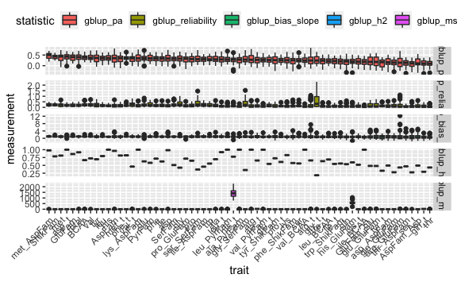

```r
gblup_summary %>%
  select(trait,
         cvnum,
         fold,
         gblup_h2,
         gblup_pa,
         gblup_reliability,
         gblup_bias_slope,
         gblup_mse) %>%
  # order by predictive accuracy (decreasing)
  mutate(trait = fct_reorder(trait, -gblup_pa)) %>%
  # convert data to long format
  gather(key = statistic, value = measurement, -trait, -cvnum, -fold) %>%
  # set factor levels for plotting
  mutate(statistic = fct_relevel(statistic, "gblup_pa", "gblup_reliability")) %>%
  ggplot(., aes(trait, measurement, fill = statistic)) +
  geom_boxplot() +
  facet_grid(statistic ~ ., scales = "free") +
  theme(axis.text.x = element_text(angle = 45, hjust = 1),
        legend.position = "top")
```

# MultiBLUP

### Visual check of cross-validations

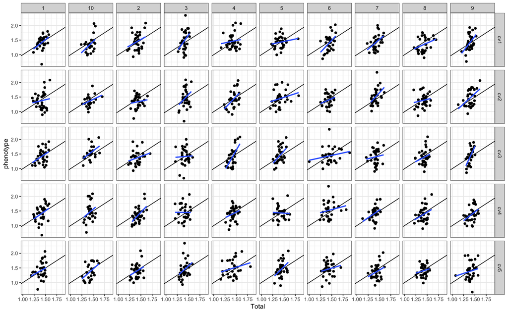

```r
multiblup_pa %>%
  filter(trait %in% "ala" & pathway %in% "aa_deg_bcat_haplo") %>%
  ggplot(aes(x = Total, y = phenotype)) +
  geom_abline(intercept = 0, slope = 1) +
  geom_point() +
  geom_smooth(method = "lm", se = FALSE) +
  facet_grid(cvnum ~ fold) +
  theme_bw()
```